# Reporting with R Markdown Practice

Inna Smirnova

2023-03-29

## Exercises using the gapminder data

First we’re going to start out with a few questions about the gapminder dataset.

### [1]

The very first step is to read in the gapminder dataset, so do that first! Also load the tidyverse package.

```r
library(tidyverse)
gapminder_data <- read_csv("Desktop/un-report/data/gapminder_data.csv")
```

## Investigating population over time.

### [2]

Make a scatter plot of year vs. population, separated into a plot for each contient. Hint: you can use facet_wrap(vars(column_name)) to separate into different plots based on that column.

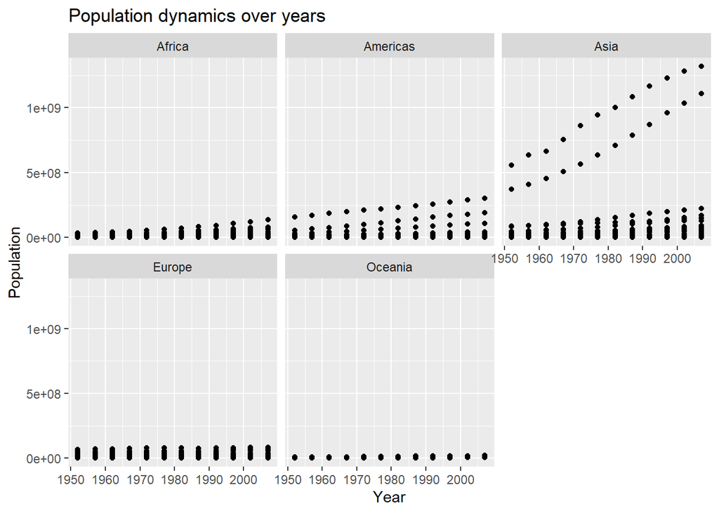

```r
ggplot(data=gapminder_data) +
  aes(x=year, y=pop) +
  geom_point() +
  facet_wrap(vars(continent)) +
  labs(x="Year",
       y="Population",
       title="Population dynamics over years")
```

### [3]

It seems like there are 2 outliers - which countries are those?

```r
# Americas and Asia seem to have some outlying countries

gapminder_data %>%
  filter(continent== "Americas") %>%
  group_by(country) %>%
  summarize(mean_pop=mean(pop/1000000)) # United States is the largest here but is still close to other countries
```

```
## # A tibble: 25 × 2
##    country            mean_pop
##    <chr>                 <dbl>
##  1 Argentina             28.6
##  2 Bolivia                5.61
##  3 Brazil               122.
##  4 Canada                24.5
##  5 Chile                 11.2
##  6 Colombia              27.3
##  7 Costa Rica             2.40
##  8 Cuba                   9.23
##  9 Dominican Republic     5.74
## 10 Ecuador                8.21
## # … with 15 more rows
```

```r
gapminder_data %>%
  filter(continent== "Asia") %>%
  group_by(country) %>%
  summarize(mean_pop=mean(pop/1000000)) # China and India are extra large - these are outliers
```

```
## # A tibble: 33 × 2
##    country         mean_pop
##    <chr>              <dbl>
##  1 Afghanistan       15.8
##  2 Bahrain            0.374
##  3 Bangladesh        90.8
##  4 Cambodia           8.51
##  5 China            958.
##  6 Hong Kong China    4.79
##  7 India            701.
##  8 Indonesia        148.
##  9 Iran              42.3
## 10 Iraq              14.2
## # … with 23 more rows
```

Two outlier countries are China and India.

### [4]

Plot year vs. population separated into a plot for each continent but excluding the 2 outlier countries.

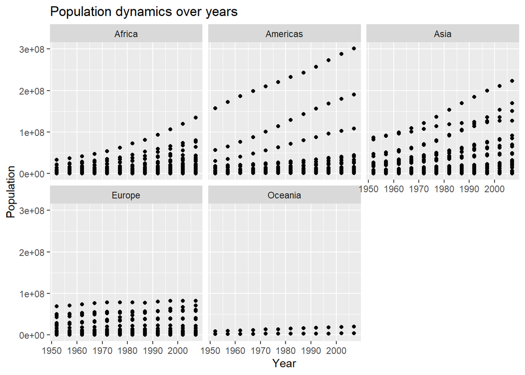

```r
gapminder_data_reduced <- gapminder_data %>%
  filter(country!= "China" & country!="India")

ggplot(data=gapminder_data_reduced) +
  aes(x=year, y=pop) +
  geom_point() +
  facet_wrap(vars(continent)) +
  labs(x="Year",
       y="Population",
       title="Population dynamics over years")
```

## Bonus questions: come back to these if you have time at the end

### [5]

In the plot above, the years look kind of messy. Can you rotate the x axis text 90 degrees so that the years are more readable? Feel free to search the internet if you don’t know how to do this!

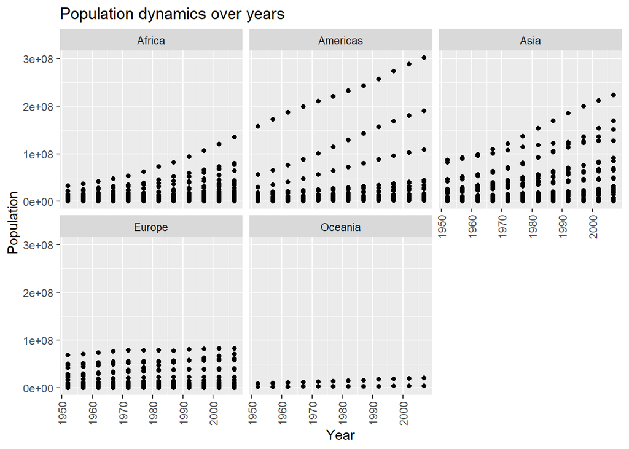

```r
ggplot(data=gapminder_data_reduced) +
  aes(x=year, y=pop) +
  geom_point() +
  facet_wrap(vars(continent)) +
  labs(x="Year",
       y="Population",
       title="Population dynamics over years") +
  theme(axis.text.x = element_text(angle = 90, vjust = 0.5, hjust = 0.8))
```

### [6]

It’s hard to see which country is which here. Can you change the scatter plot to a line plot so we can get a better sense of trends over time? Hint: This website has more information: https://www.r-graph-gallery.com/line-chart-several-groups-ggplot2.html

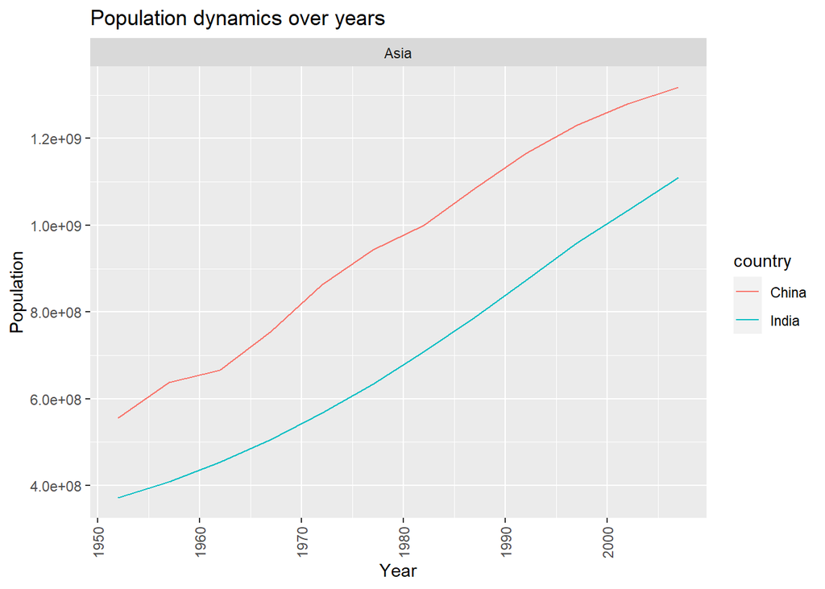

```r
gapminder_data %>% filter(country== "China" | country=="India") %>%
  ggplot() +
  aes(x=year, y=pop, group=country, color=country) +
  geom_line() +
  facet_wrap(vars(continent)) +
  labs(x="Year",
       y="Population",
       title="Population dynamics over years") +
  theme(axis.text.x = element_text(angle = 90, vjust = 0.5, hjust = 0.8))
```

## Looking into life expectancy a bit more.

### [7]

What country had the highest life expectancy in 1982? Hint: use the slice_max() function to get the row for a maximum value in a dataset. You can use ?slice_max and/or the internet to learn more about how to use the function.

```r
gapminder_data %>%
  filter(year==1982) %>%
  slice_max(lifeExp)
```

```
## # A tibble: 1 × 6
##   country  year       pop continent lifeExp gdpPercap
##   <chr>   <dbl>     <dbl> <chr>       <dbl>     <dbl>
## 1 Japan    1982 118454974 Asia         77.1    19384.
```

Japan had the highest life expectancy in the year of 1982.

### [8]

Now, do the same thing but for all years! Hint: Use the group_by() function.

```r
gapminder_data %>%
  group_by(year) %>%
  slice_max(lifeExp)
```

```
## # A tibble: 12 × 6
## # Groups:   year [12]
##    country  year       pop continent lifeExp gdpPercap
##    <chr>   <dbl>     <dbl> <chr>       <dbl>     <dbl>
##  1 Norway   1952   3327728 Europe       72.7    10095.
##  2 Iceland  1957    165110 Europe       73.5     9244.
##  3 Iceland  1962    182053 Europe       73.7    10350.
##  4 Sweden   1967   7867931 Europe       74.2    15258.
##  5 Sweden   1972   8122293 Europe       74.7    17832.
##  6 Iceland  1977    221823 Europe       76.1    19655.
##  7 Japan    1982 118454974 Asia         77.1    19384.
##  8 Japan    1987 122091325 Asia         78.7    22376.
##  9 Japan    1992 124329269 Asia         79.4    26825.
## 10 Japan    1997 125956499 Asia         80.7    28817.
## 11 Japan    2002 127065841 Asia         82      28605.
## 12 Japan    2007 127467972 Asia         82.6    31656.
```

### [9]

Make a boxplot for the life expectancies of the countries in Asia for each year (year is the x axis, life expectancy is the y axis). Also fix the x and y axis labels.

```r
gapminder_data %>%
  filter(continent=="Asia") %>%
  group_by(year) %>%
  slice_min(lifeExp)
```

```
## # A tibble: 12 × 6
## # Groups:   year [12]
##    country      year      pop continent lifeExp gdpPercap
##    <chr>       <dbl>    <dbl> <chr>       <dbl>     <dbl>
##  1 Afghanistan  1952  8425333 Asia         28.8      779.
##  2 Afghanistan  1957  9240934 Asia         30.3      821.
##  3 Afghanistan  1962 10267083 Asia         32.0      853.
##  4 Afghanistan  1967 11537966 Asia         34.0      836.
##  5 Afghanistan  1972 13079460 Asia         36.1      740.
##  6 Cambodia     1977  6978607 Asia         31.2      525.
##  7 Afghanistan  1982 12881816 Asia         39.9      978.
##  8 Afghanistan  1987 13867957 Asia         40.8      852.
##  9 Afghanistan  1992 16317921 Asia         41.7      649.
## 10 Afghanistan  1997 22227415 Asia         41.8      635.
## 11 Afghanistan  2002 25268405 Asia         42.1      727.
## 12 Afghanistan  2007 31889923 Asia         43.8      975.
```

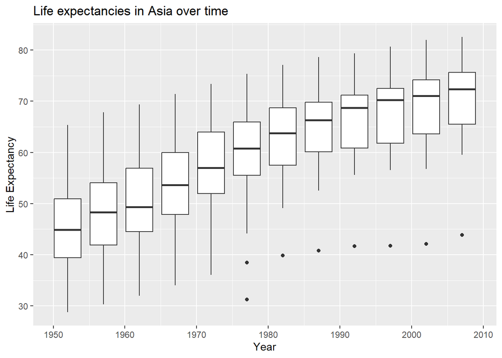

```r
gapminder_data %>%
  filter(continent=="Asia") %>%
  #filter(country!="Afghanistan") %>%  # outlier on the graph
  ggplot() +
  aes(x=year, y=lifeExp, group=year) +
  geom_boxplot() +
  labs(x="Year",
       y="Life Expectancy",
       title="Life expectancies in Asia over time")
```

## Bonus questions: come back to these if you have time at the end

### [10]

What are the outliers in life expectancy in Asia for each year (lower life expectancy)?

```r
gapminder_data %>%
  filter(continent=="Asia") %>%
  group_by(year) %>%
  slice_min(lifeExp)
```

```
## # A tibble: 12 × 6
## # Groups:   year [12]
##    country      year      pop continent lifeExp gdpPercap
##    <chr>       <dbl>    <dbl> <chr>       <dbl>     <dbl>
##  1 Afghanistan  1952  8425333 Asia         28.8      779.
##  2 Afghanistan  1957  9240934 Asia         30.3      821.
##  3 Afghanistan  1962 10267083 Asia         32.0      853.
##  4 Afghanistan  1967 11537966 Asia         34.0      836.
##  5 Afghanistan  1972 13079460 Asia         36.1      740.
##  6 Cambodia     1977  6978607 Asia         31.2      525.
##  7 Afghanistan  1982 12881816 Asia         39.9      978.
##  8 Afghanistan  1987 13867957 Asia         40.8      852.
##  9 Afghanistan  1992 16317921 Asia         41.7      649.
## 10 Afghanistan  1997 22227415 Asia         41.8      635.
## 11 Afghanistan  2002 25268405 Asia         42.1      727.
## 12 Afghanistan  2007 31889923 Asia         43.8      975.
```

### [11]

Make a boxplot for the life expectancies of the countries over time for each continent. Try to fix the x and y axis labels and text, too. Feel free to change the theme if you’d like.

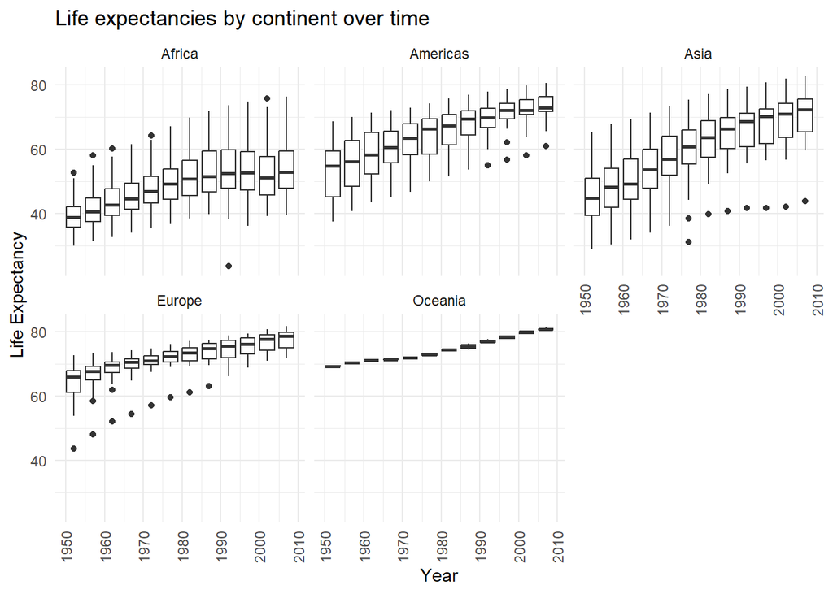

```r
gapminder_data %>%
  ggplot() +
  aes(x=year, y=lifeExp, group=year) +
  geom_boxplot() +
  facet_wrap(vars(continent)) +
  labs(x="Year",
       y="Life Expectancy",
       title="Life expectancies by continent over time") +
  theme_minimal() +
  theme(axis.text.x = element_text(angle = 90, vjust = 0.5, hjust = 0.8))
```

### [12]

Which country has had the greatest increase in life expectancy from 1952 to 2007? Hint: You might want to use the pivot_wider() function to get your data in a format with columns for: country, 1952 life expectancy, 2007 life expectancy, and the difference between 2007 and 1992 life expectancy.

```r
gapminder_data %>%
  filter(year==1952 | year==2007) %>%
  select(country, year, lifeExp) %>%
  mutate(year=recode(year, "1952"="year_1952", "2007"="year_2007")) %>%
  pivot_wider(names_from = year, values_from = lifeExp) %>%
  mutate(lifeExp_diff=year_2007-year_1952) %>%
  slice_max(lifeExp_diff)
```

```
## # A tibble: 1 × 4
##   country year_1952 year_2007 lifeExp_diff
##   <chr>       <dbl>     <dbl>        <dbl>
## 1 Oman         37.6      75.6         38.1
```

Oman has had the highest life expectancy increase over years.

### [13]

What countries had a decrease in life expectancy from 1952 to 2007?

```r
gapminder_data %>%
  filter(year==1952 | year==2007) %>%
  select(country, year, lifeExp) %>%
  mutate(year=recode(year, "1952"="year_1952", "2007"="year_2007")) %>%
  pivot_wider(names_from = year, values_from = lifeExp) %>%
  mutate(lifeExp_diff=year_2007-year_1952) %>%
  filter(lifeExp_diff<0)
```

```
## # A tibble: 2 × 4
##   country   year_1952 year_2007 lifeExp_diff
##   <chr>         <dbl>     <dbl>        <dbl>
## 1 Swaziland      41.4      39.6        -1.79
## 2 Zimbabwe       48.5      43.5        -4.96
```

Swaziland and Zimbabwe have had a decrease in life expectancy over years.